# WHITE WINE DATA ANALYSIS by AKASH PATEL

```
##   X fixed.acidity volatile.acidity citric.acid residual.sugar chlorides
## 1 1           7.0             0.27        0.36           20.7     0.045
## 2 2           6.3             0.30        0.34            1.6     0.049
## 3 3           8.1             0.28        0.40            6.9     0.050
## 4 4           7.2             0.23        0.32            8.5     0.058
## 5 5           7.2             0.23        0.32            8.5     0.058
##   free.sulfur.dioxide total.sulfur.dioxide density   pH sulphates alcohol
## 1                  45                  170  1.0010 3.00      0.45     8.8
## 2                  14                  132  0.9940 3.30      0.49     9.5
## 3                  30                   97  0.9951 3.26      0.44    10.1
## 4                  47                  186  0.9956 3.19      0.40     9.9
## 5                  47                  186  0.9956 3.19      0.40     9.9
##   quality
## 1       6
## 2       6
## 3       6
## 4       6
## 5       6
```

```
##   fixed.acidity volatile.acidity citric.acid residual.sugar chlorides
## 1             7             0.27        0.36           20.7     0.045
##   free.sulfur.dioxide total.sulfur.dioxide density pH sulphates alcohol quality
## 1                  45                  170   1.001  3      0.45     8.8       6
```

The white wine dataset consists of 4898 observations and 13 variables. The data includes wine properties such as, alcohol level, quality of the wine, and acidity which we will explore and anaylze.

# Univariate Plots Section

```
##  fixed.acidity    volatile.acidity  citric.acid     residual.sugar
##  Min.   : 3.800   Min.   :0.0800   Min.   :0.0000   Min.   : 0.600
##  1st Qu.: 6.300   1st Qu.:0.2100   1st Qu.:0.2700   1st Qu.: 1.700
##  Median : 6.800   Median :0.2600   Median :0.3200   Median : 5.200
##  Mean   : 6.855   Mean   :0.2782   Mean   :0.3342   Mean   : 6.391
##  3rd Qu.: 7.300   3rd Qu.:0.3200   3rd Qu.:0.3900   3rd Qu.: 9.900
##  Max.   :14.200   Max.   :1.1000   Max.   :1.6600   Max.   :65.800
##    chlorides       free.sulfur.dioxide total.sulfur.dioxide    density
##  Min.   :0.00900   Min.   :  2.00      Min.   :  9.0        Min.   :0.9871
##  1st Qu.:0.03600   1st Qu.: 23.00      1st Qu.:108.0        1st Qu.:0.9917
##  Median :0.04300   Median : 34.00      Median :134.0        Median :0.9937
##  Mean   :0.04577   Mean   : 35.31      Mean   :138.4        Mean   :0.9940
##  3rd Qu.:0.05000   3rd Qu.: 46.00      3rd Qu.:167.0        3rd Qu.:0.9961
##  Max.   :0.34600   Max.   :289.00      Max.   :440.0        Max.   :1.0390
##        pH          sulphates         alcohol         quality
##  Min.   :2.720   Min.   :0.2200   Min.   : 8.00   Min.   :3.000
##  1st Qu.:3.090   1st Qu.:0.4100   1st Qu.: 9.50   1st Qu.:5.000
##  Median :3.180   Median :0.4700   Median :10.40   Median :6.000
##  Mean   :3.188   Mean   :0.4898   Mean   :10.51   Mean   :5.878
##  3rd Qu.:3.280   3rd Qu.:0.5500   3rd Qu.:11.40   3rd Qu.:6.000
##  Max.   :3.820   Max.   :1.0800   Max.   :14.20   Max.   :9.000
```

```
## 'data.frame':    4898 obs. of  12 variables:
##  $ fixed.acidity       : num  7 6.3 8.1 7.2 7.2 8.1 6.2 7 6.3 8.1 ...
##  $ volatile.acidity    : num  0.27 0.3 0.28 0.23 0.23 0.28 0.32 0.27 0.3 0.22 ...
##  $ citric.acid         : num  0.36 0.34 0.4 0.32 0.32 0.4 0.16 0.36 0.34 0.43 ...
##  $ residual.sugar      : num  20.7 1.6 6.9 8.5 8.5 6.9 7 20.7 1.6 1.5 ...
##  $ chlorides           : num  0.045 0.049 0.05 0.058 0.058 0.05 0.045 0.045 0.049 0.044 ...
##  $ free.sulfur.dioxide : num  45 14 30 47 47 30 30 45 14 28 ...
##  $ total.sulfur.dioxide: num  170 132 97 186 186 97 136 170 132 129 ...
##  $ density             : num  1.001 0.994 0.995 0.996 0.996 ...
##  $ pH                  : num  3 3.3 3.26 3.19 3.19 3.26 3.18 3 3.3 3.22 ...
##  $ sulphates           : num  0.45 0.49 0.44 0.4 0.4 0.44 0.47 0.45 0.49 0.45 ...
##  $ alcohol             : num  8.8 9.5 10.1 9.9 9.9 10.1 9.6 8.8 9.5 11 ...
##  $ quality             : int  6 6 6 6 6 6 6 6 6 6 ...
```

```
##  [1] "fixed.acidity"        "volatile.acidity"     "citric.acid"
##  [4] "residual.sugar"       "chlorides"            "free.sulfur.dioxide"
##  [7] "total.sulfur.dioxide" "density"              "pH"
## [10] "sulphates"            "alcohol"              "quality"
```

```
## [1] 4898   12
```

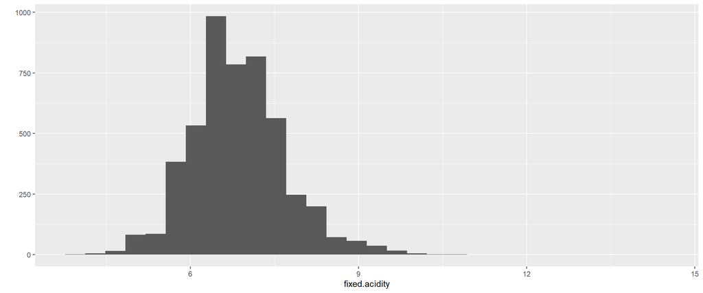

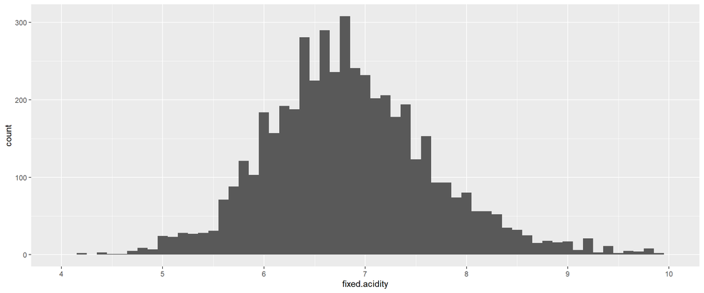

```
##    Min. 1st Qu.  Median    Mean 3rd Qu.    Max.
##   3.800   6.300   6.800   6.855   7.300  14.200
```

Fixed acidity follows a normal distribution. Mean is 6.85, and median 6.8

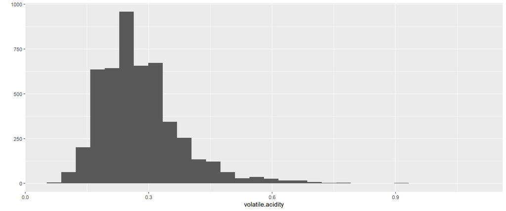

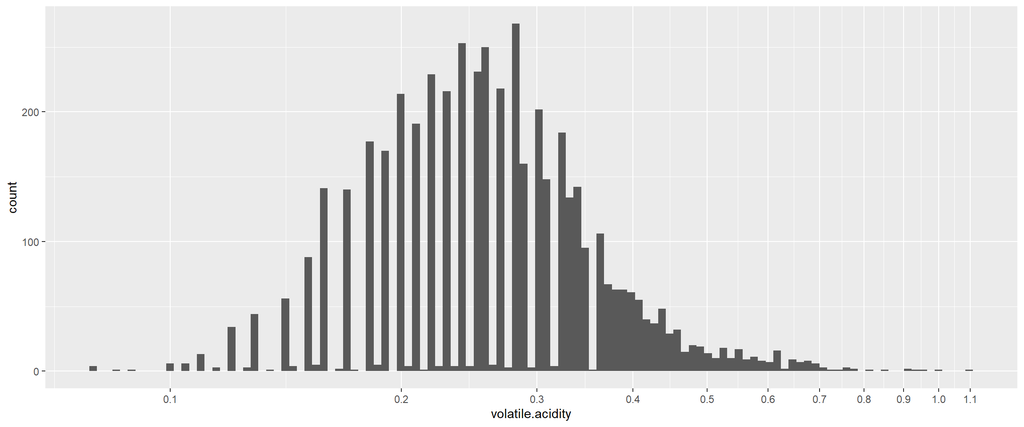

```
##    Min. 1st Qu.  Median    Mean 3rd Qu.    Max.
##  0.0800  0.2100  0.2600  0.2782  0.3200  1.1000
```

Volatile acidits appears normal distribution after transforming the long tail data.

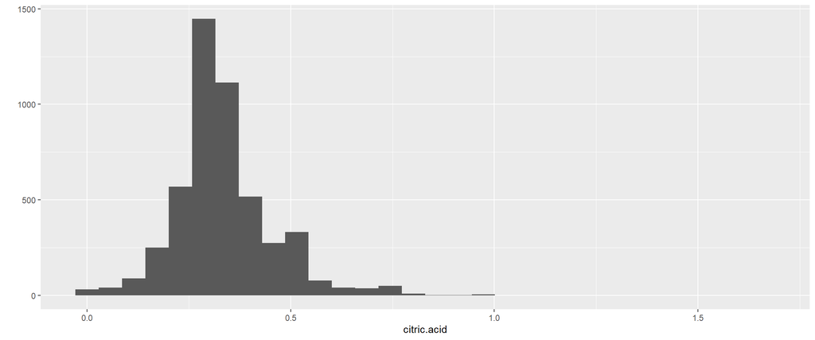

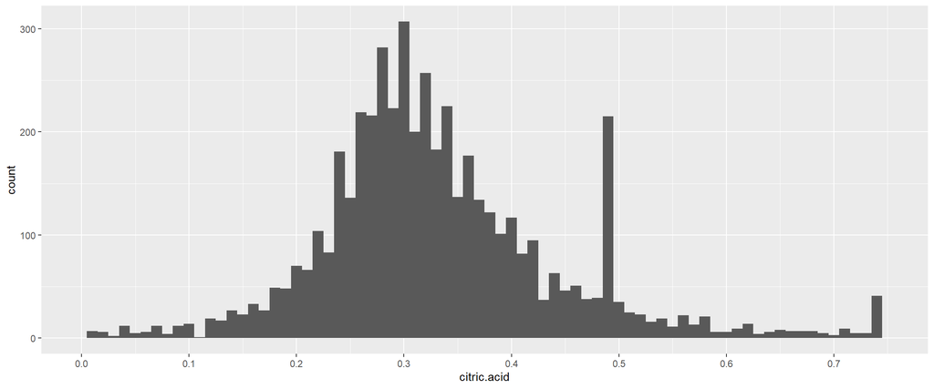

```
##    Min. 1st Qu.  Median    Mean 3rd Qu.    Max.
##  0.0000  0.2700  0.3200  0.3342  0.3900  1.6600
```

Citric acid follows a normal distribution. Mean is 0.33 and median is 0.32.

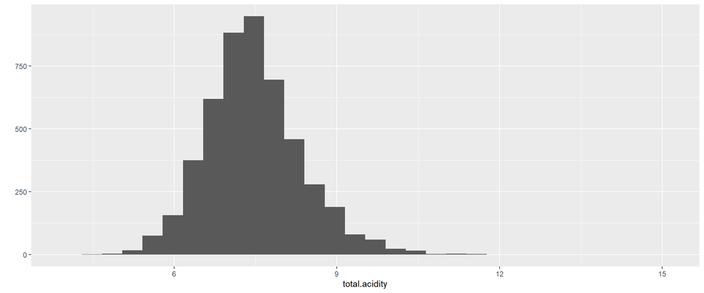

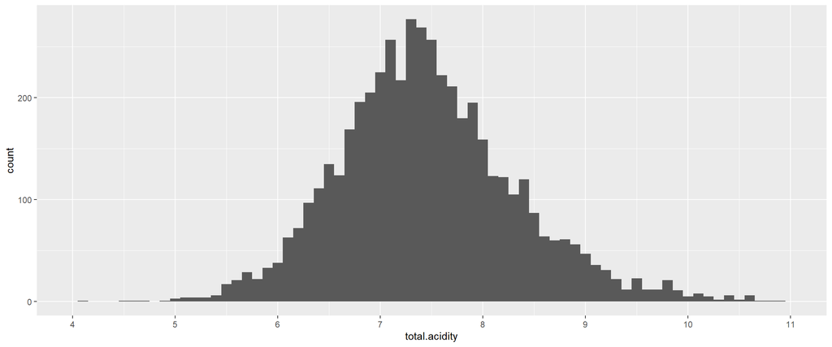

```
##    Min. 1st Qu.  Median    Mean 3rd Qu.    Max.
##   4.130   6.890   7.405   7.467   7.960  14.960
```

Combined all the acidity variables to create a total acidity for analyszing

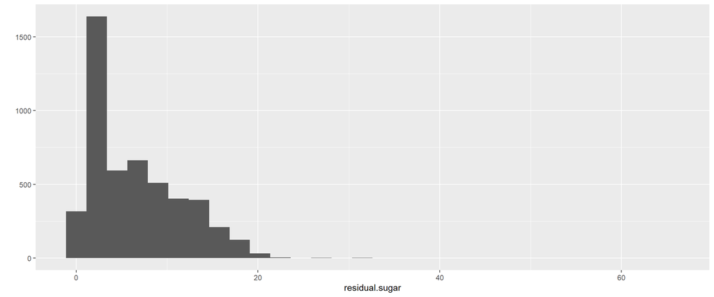

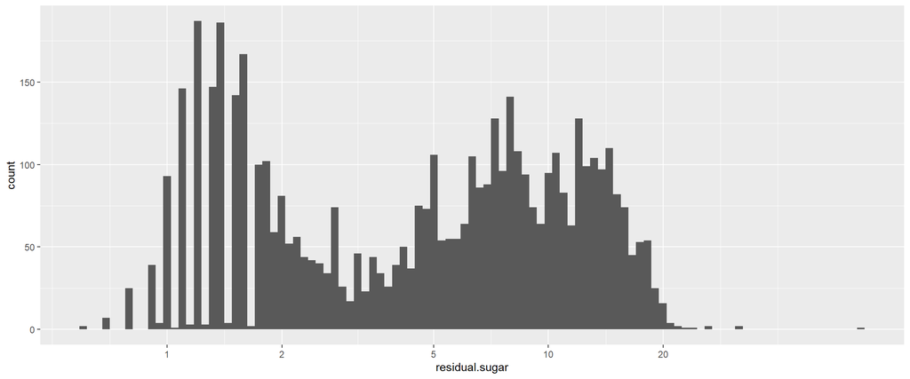

```
##    Min. 1st Qu.  Median    Mean 3rd Qu.    Max.
##   0.600   1.700   5.200   6.391   9.900  65.800
```

Residual sugar has likely the most unsual distribution.

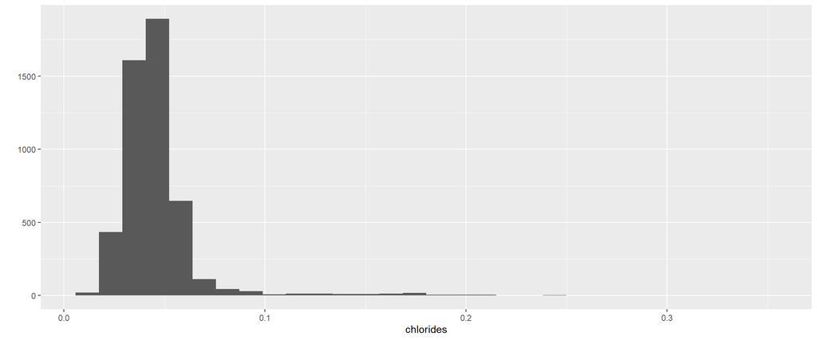

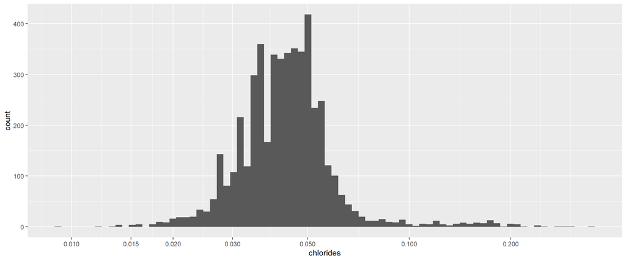

```
##    Min. 1st Qu.  Median    Mean 3rd Qu.    Max.
## 0.00900 0.03600 0.04300 0.04577 0.05000 0.34600
```

Most chlorides are between 0.036 and 0.05.

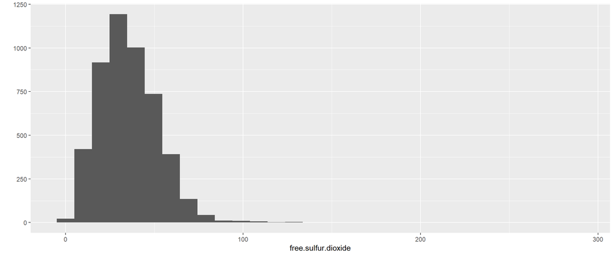

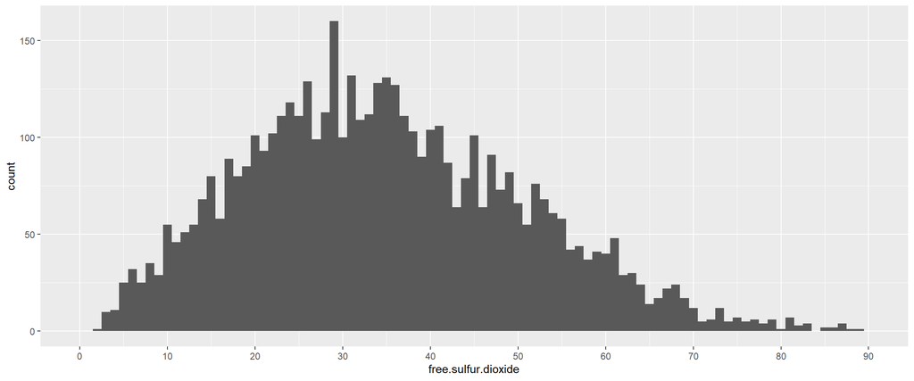

```
##    Min. 1st Qu.  Median    Mean 3rd Qu.    Max.
##    2.00   23.00   34.00   35.31   46.00  289.00
```

Free sulfur dioxide follows a normal distriburtion. Mean is 35.31 and median is 34

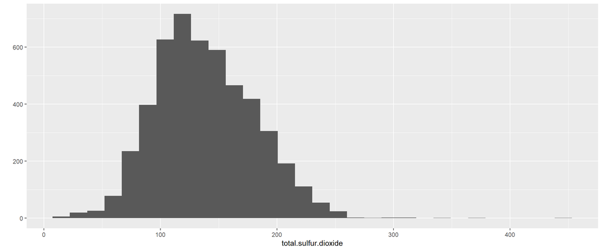

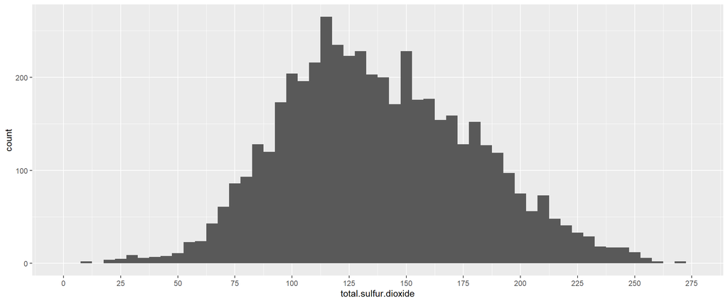

```
##    Min. 1st Qu.  Median    Mean 3rd Qu.    Max.
##     9.0   108.0   134.0   138.4   167.0   440.0
```

Total sulfur dioxide follows a normal distriburtion. Mean is 138.4 and median is 134.

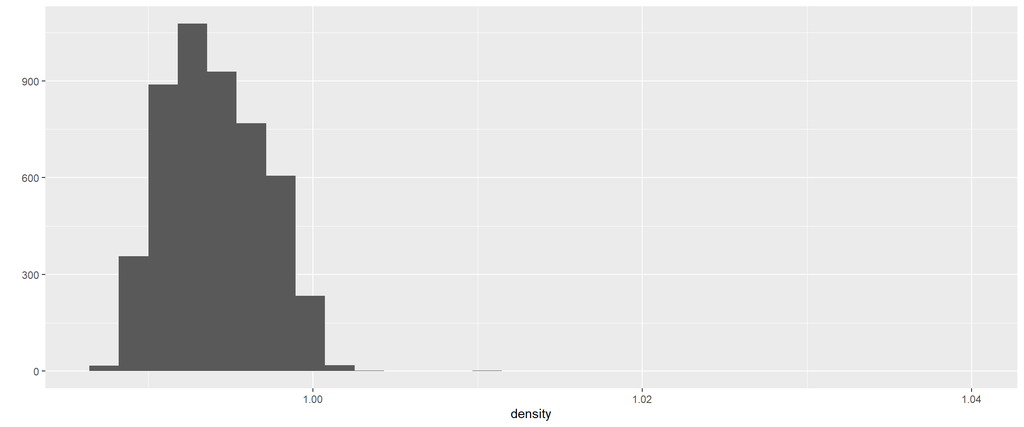

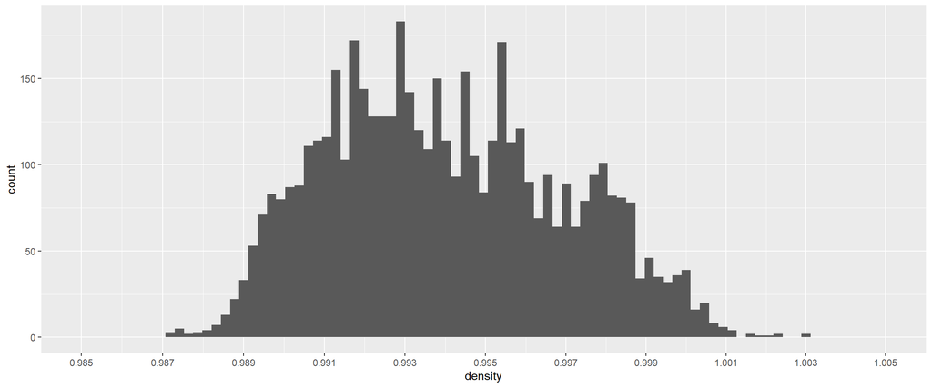

```
##    Min. 1st Qu.  Median    Mean 3rd Qu.    Max.
##  0.9871  0.9917  0.9937  0.9940  0.9961  1.0390
```

Density follows a normal distribution. Mean and median are 0.993 with some outliers over 1.

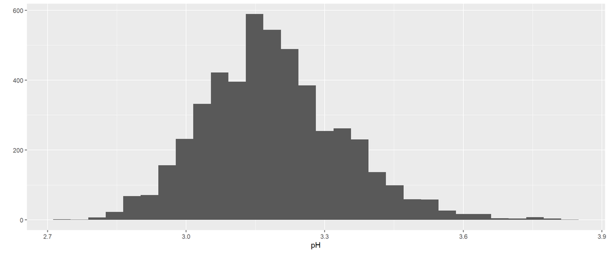

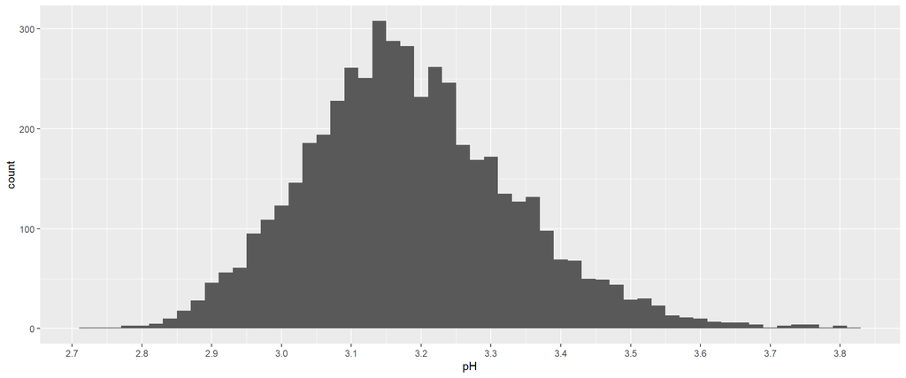

```
##    Min. 1st Qu.  Median    Mean 3rd Qu.    Max.
##   2.720   3.090   3.180   3.188   3.280   3.820
```

The graph of pH is normally distributed and concentraetd around 3.13. lowest is 2.72, and max is 3.82.

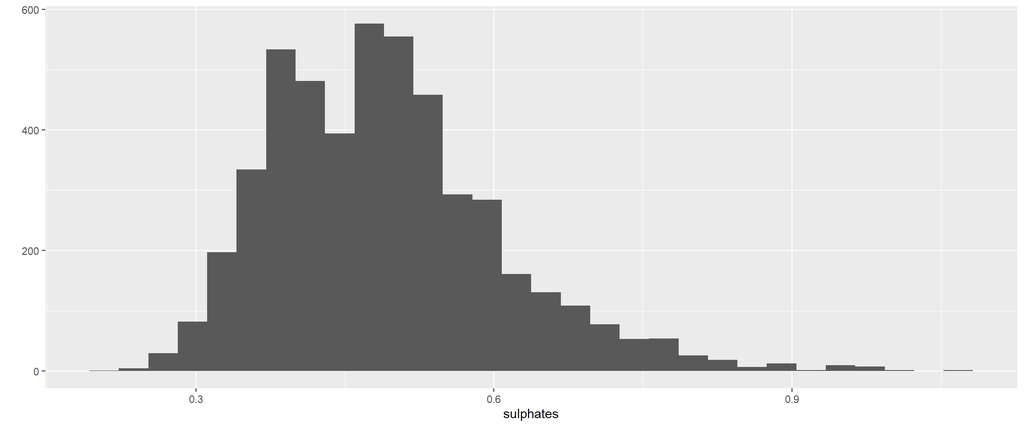

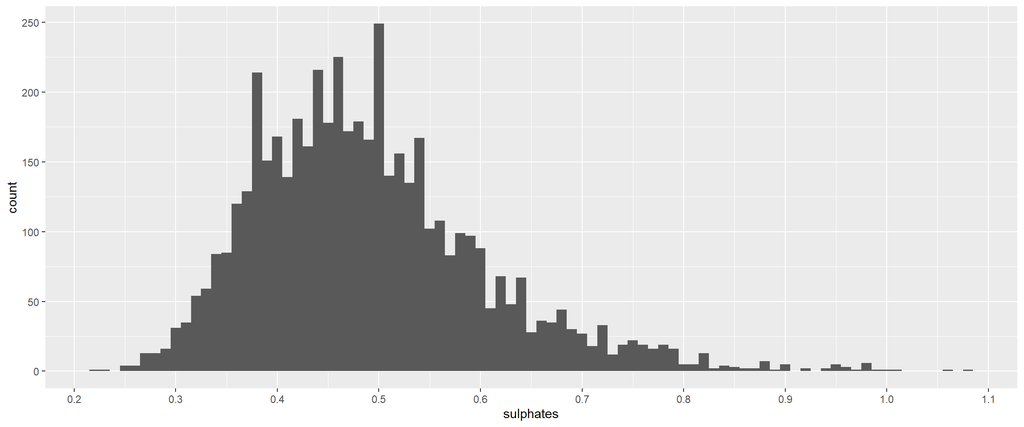

```
##    Min. 1st Qu.  Median    Mean 3rd Qu.    Max.
##  0.2200  0.4100  0.4700  0.4898  0.5500  1.0800
```

Sulphates follows a right skewer normal distribution.

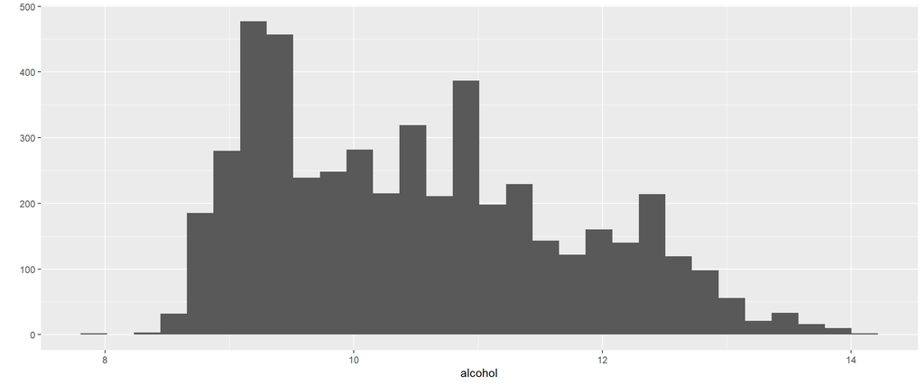

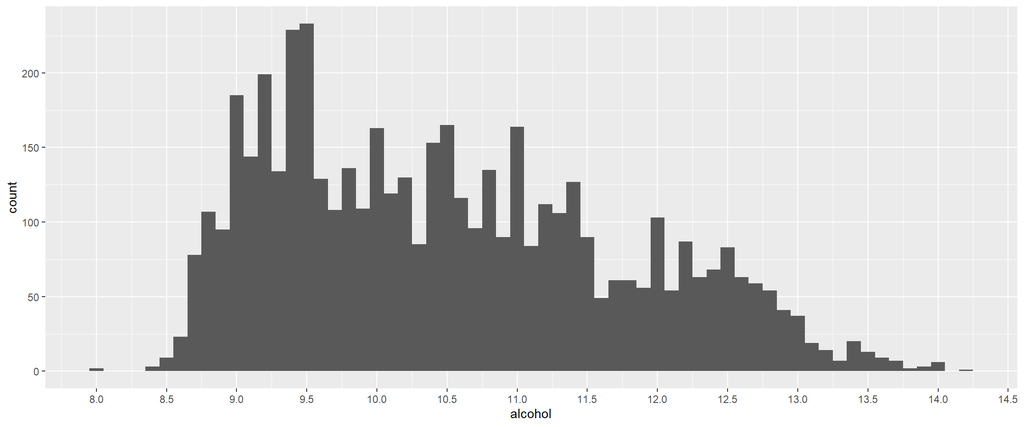

```
##    Min. 1st Qu.  Median    Mean 3rd Qu.    Max.
##    8.00    9.50   10.40   10.51   11.40   14.20
```

Most alcohol values are around 9.5 and is rightly skewed.

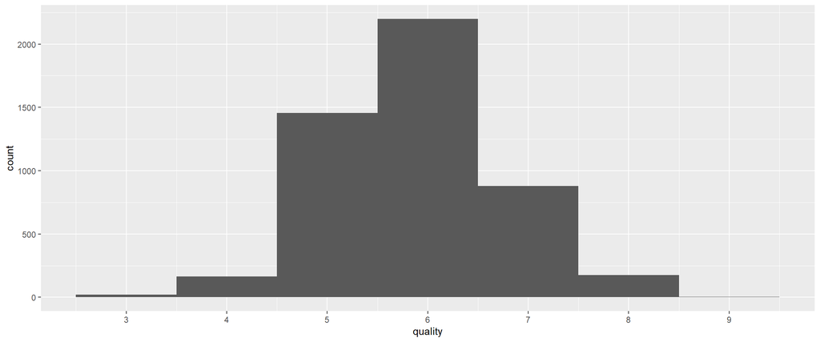

```
##    Min. 1st Qu.  Median    Mean 3rd Qu.    Max.
##   3.000   5.000   6.000   5.878   6.000   9.000
```

Most quality is between 5 and 7, with 6 being the common quality. The mean value is 5.878, the lowest is 3, and max quality is 9.

# Univariate Analysis

### What is the structure of your dataset?

As stated earlier, there are 4898 dataset with 12 different variables + 1 we created (Total_acidity). All variables are numeric

### What is/are the main feature(s) of interest in your dataset?

The main features of interest from the dataset are the latter variables (acidity, alcohol, sugar, density, ph, and quality).

### What other features in the dataset do you think will help support your

investigation into your feature(s) of interest?

I think sugar content can reasonably influence the quality of the wine. Lower the sugar content, the higher the wine quality.

### Did you create any new variables from existing variables in the dataset?

I created total_acidity variable, which is a comibation of all the acids (fixed.acidity + volatile.acidity + citric.acid)

### Of the features you investigated, were there any unusual distributions?

# Bivariate Plots Section

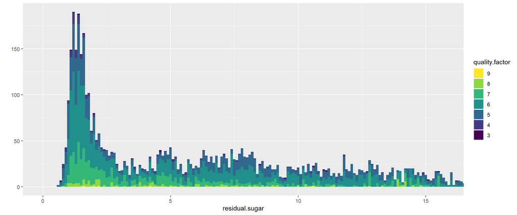

```
## quality: 3
##    Min. 1st Qu.  Median    Mean 3rd Qu.    Max.
##   0.700   1.587   4.600   6.393  10.700  16.200
## ------------------------------------------------------------
## quality: 4
##    Min. 1st Qu.  Median    Mean 3rd Qu.    Max.
##   0.700   1.300   2.500   4.628   7.100  17.550
## ------------------------------------------------------------
## quality: 5
##    Min. 1st Qu.  Median    Mean 3rd Qu.    Max.
##   0.600   1.800   7.000   7.335  11.500  23.500
## ------------------------------------------------------------
## quality: 6
##    Min. 1st Qu.  Median    Mean 3rd Qu.    Max.
##   0.700   1.700   5.300   6.442   9.900  65.800
## ------------------------------------------------------------
## quality: 7
##    Min. 1st Qu.  Median    Mean 3rd Qu.    Max.
##   0.900   1.700   3.650   5.186   7.325  19.250
## ------------------------------------------------------------
## quality: 8
##    Min. 1st Qu.  Median    Mean 3rd Qu.    Max.
##   0.800   2.100   4.300   5.671   8.200  14.800
## ------------------------------------------------------------
## quality: 9
##    Min. 1st Qu.  Median    Mean 3rd Qu.    Max.
##    1.60    2.00    2.20    4.12    4.20   10.60
```

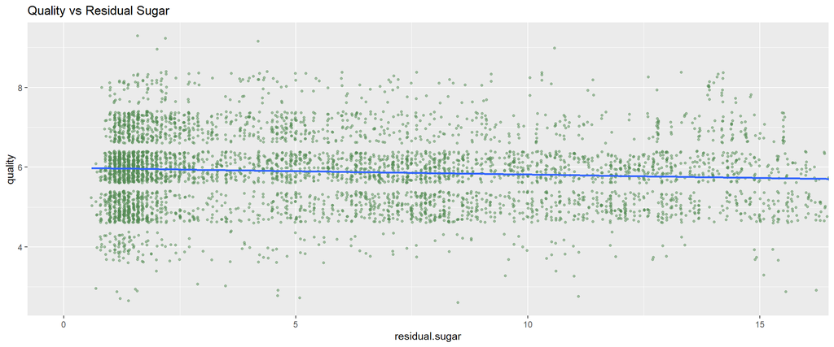

Quality decreases slightly as more sugar presense in the wine.

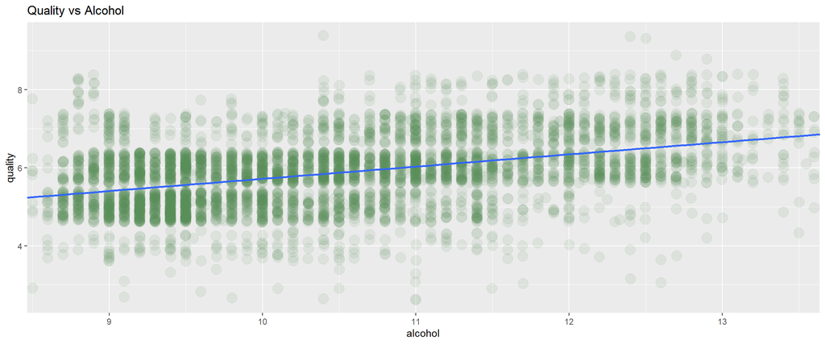

As we can assume by looking at the liner graph (Quality vs Alcohol) that quality of wine increases with more alcohol graduation.

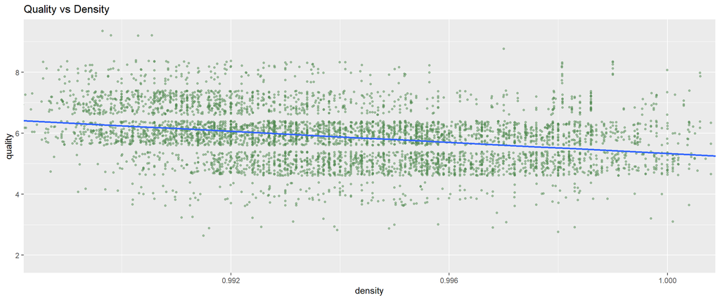

Higher quality of 7 or more will have lower density

# Bivariate Analysis

### Talk about some of the relationships you observed in this part of the

investigation. How did the feature(s) of interest vary with other features in  
the dataset?

Higher quality wines have higher alcohol content, lower density levels, and lower sugar levels

### Did you observe any interesting relationships between the other features

(not the main feature(s) of interest)?

I did not observe any interesting relationships with other features.

### What was the strongest relationship you found?

# Multivariate Plots Section

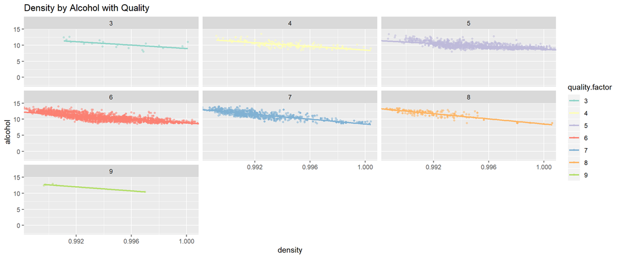

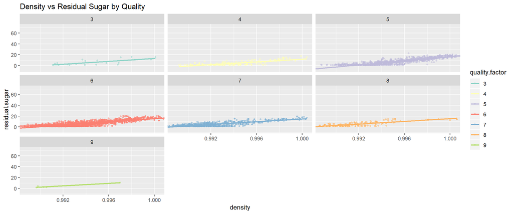

The correlation exists for quality seems that values goes from right to left in the linera model as quality increases.

# Multivariate Analysis

### Talk about some of the relationships you observed in this part of the

investigation. Were there features that strengthened each other in terms of  
looking at your feature(s) of interest?

### Were there any interesting or surprising interactions between features?

The most interesting variable is density with alcohol and sugar.